v1.3

# Objective

- The objective of this **01.01** notebook is to
  - clean the original text in the datasets
  - create pre- and post-cleaning text stats

# Pre-checks

```python
## Check for Google Drive Connectivity
try:
    from google.colab import drive
    drive.mount('/content/drive')
    google_env = True
except:
    print("Not a Goolge Drive Environment.")
    google_env = False
```

```
Not a Goolge Drive Environment.
```

```python
import time
t_start = time.time()
```

```python
# Use parameters to enable/disable the fastrun

FASTRUN = False
#FASTRUN = True

# Size of the fastrun dataframe
sample_fraction = 0.1
print("==="*40)
print("Fastrun enabled:", FASTRUN)
if FASTRUN: print("Sample size:",sample_fraction)
print("==="*40)
```

```
========================================================================================================================
Fastrun enabled: False
========================================================================================================================
```

# Setup Environment

## Install Modules

```python
#!pip install pandas --upgrade
#!pip install watermark
#!pip install textstat
#!pip install nltk
#!pip install fasttext-langdetect
```

```python
#import nltk
#nltk.download('popular')
#nltk.download('stopwords')
```

## Import Modules

```python
# Base libraries
import os
import re
from datetime import date

# Scientific libraries
import numpy as np
import pandas as pd

# Specific libraries
import textstat
from ftlangdetect import detect
from nltk.corpus import stopwords

# Visualization
import seaborn as sns
sns.set(rc={'figure.figsize':(8,4)})
sns.set(font_scale=0.8)

# Helper libraries
from tqdm import tqdm
tqdm.pandas()
from watermark import watermark
import gc # garbage collection to optimize memory usage, use gc.collect()
import warnings
warnings.filterwarnings('ignore')

# Pandas options
pd.set_option('display.max_rows', None)
pd.set_option('display.max_columns', None)
pd.set_option('display.width', None)
pd.set_option('display.max_colwidth', None)

from IPython.core.interactiveshell import InteractiveShell
InteractiveShell.ast_node_interactivity = 'all'

# Load magic commands
%load_ext watermark
```

## Define Parameters

```python
seed = 42
cpu_count = os.cpu_count()
cpu_count = cpu_count-2  # to keep machine responsive when fitting the models
notebook_no = "01.01"
today = date.today()
```

## Global Helper Functions

```python
import http.client
import urllib


def send_push(message):
    """Send push notifications to pushover service."""
    try:
        conn = http.client.HTTPSConnection("api.pushover.net:443")
        conn.request("POST", "/1/messages.json",
                     urllib.parse.urlencode({
                         "token": "ahs1q4mwpnxe3645zeaqzas69whq7a",  # ML Notifications Channel
                         "user": "u5vr1qkc9ghudg2ehuug153okeiz1d",
                         "message": message,
                     }), {"Content-type": "application/x-www-form-urlencoded"})

        conn.getresponse()

    except:
        print("There was a communication issue (pushover).")
```

# 3.0 Load Data

https://www.kaggle.com/competitions/umich-siads-696-f22-predicting-text-difficulty/

```python
# Load Data
if google_env:
    # Location for "shared with" people
    # create a shortcut of the shared folder in your Google Drive root folder
    ROOT_PATH = "/content/drive/MyDrive/SIADS696/Environment/"
else:
    ROOT_PATH = "../"
    print("Not a Google Drive Environment. Loading local files.")

PATH_DATA = "data/"
PATH_DATA_RAW = "data/raw/"
PATH_DATA_INT = "data/interim/"
PATH_DATA_PRO = "data/processed/"
PATH_DATA_MOD = "models/"
PATH_DATA_REP = "reports/"
PATH_DATA_FIG = "reports/figures/"
PATH_DATA_HTML = "reports/html/"

df_wiki_train = pd.read_csv(ROOT_PATH+PATH_DATA_RAW+"WikiLarge_Train.csv")
df_wiki_test = pd.read_csv(ROOT_PATH+PATH_DATA_RAW+"WikiLarge_Test.csv")
```

```
Not a Google Drive Environment. Loading local files.
```

```python
df_wiki_train.info()
df_wiki_train.shape
```

```
<class 'pandas.core.frame.DataFrame'>
RangeIndex: 416768 entries, 0 to 416767
Data columns (total 2 columns):
 #   Column         Non-Null Count   Dtype
---  ------         --------------   -----
 0   original_text  416768 non-null  object
 1   label          416768 non-null  int64
dtypes: int64(1), object(1)
memory usage: 6.4+ MB
```

```
(416768, 2)
```

```python
df_wiki_test.info()
df_wiki_test.shape
```

```
<class 'pandas.core.frame.DataFrame'>
RangeIndex: 119092 entries, 0 to 119091
Data columns (total 3 columns):
 #   Column         Non-Null Count   Dtype
---  ------         --------------   -----
 0   id             119092 non-null  int64
 1   original_text  119092 non-null  object
 2   label          0 non-null       float64
dtypes: float64(1), int64(1), object(1)
memory usage: 2.7+ MB
```

```
(119092, 3)
```

# 4.0 Data Cleaning and Feature Engineering

**Tips on Creating Features**

- Linear models learn sums and differences naturally, but can't learn anything more complex.
- Ratios seem to be difficult for most models to learn. Ratio combinations often lead to some easy performance gains.
- Linear models and neural nets generally do better with normalized features. Neural nets especially need features scaled to values not too far from 0. Tree-based models (like random forests and XGBoost) can sometimes benefit from normalization, but usually much less so.
- Tree models can learn to approximate almost any combination of features, but when a combination is especially important they can still benefit from having it explicitly created, especially when data is limited.
- Counts are especially helpful for tree models, since these models don't have a natural way of aggregating information across many features at once.

[Source](https://www.kaggle.com/code/ryanholbrook/creating-features)

## Pre-Cleaning Feature Construction (stats)

```python
import textstat
textstat.set_lang('en')
```

```python
from sklearn.preprocessing import LabelEncoder
le = LabelEncoder()


def count_patterns(text, pattern):
    return len(re.findall(pattern, text))


def detect_lang(text):
    #https://pypi.org/project/fasttext-langdetect/
    result = detect(text, low_memory=False)['lang']
    return result

def detect_complete_sentence(text):
    # We assume that a complete sentence ends with a dot. The other samples are parsing errors.
    if text.startswith("Image : ")\
            or ("ISBN" in text)\
            or ("frac" in text)\
            or text.startswith("frac")\
            or text.startswith("m _")\
            or text.startswith("File :")\
            or text.startswith("-LRB- x ")\
            or text.startswith("Õ"):
        return 0

    elif text.endswith("."):  # sentence length will be check later with cleaned text
        return 1


def detect_image_desc(text):
    if text.startswith("Image : "):
        return 1
    else:
        return 0


def detect_frac_desc(text):
    if text.startswith("frac"):
        return 1
    else:
        return 0


def detect_file_desc(text):
    if text.startswith("File :"):
        return 1
    else:
        return 0


def detect_formula_desc(text):
    if text.startswith("m _"):
        return 1
    else:
        return 0


def pre_clean_calculate_text_stats(df):
    #df['stats_umlaut_count'] = df['original_text'].progress_apply(lambda x: count_patterns(x, "ü|ö|ä"))    # not really important
    #df['stats_numbers_count'] = df['original_text'].progress_apply(lambda x: count_patterns(x, "(\d+)"))   # not really important
    #df['stats_semicolon_count'] = df['original_text'].progress_apply(lambda x: count_patterns(x, ";"))     # not really important
    #df['stats_colon_count'] = df['original_text'].progress_apply(lambda x: count_patterns(x, ":"))         # not really important

    df['stats_lrb_count'] = df['original_text'].progress_apply(lambda x: count_patterns(x, "-LRB-"))
    df['stats_rrb_count'] = df['original_text'].progress_apply(lambda x: count_patterns(x, "-RRB-"))
    df['stats_comma_count'] = df['original_text'].progress_apply(lambda x: count_patterns(x, ","))
    df['stats_equalsign_count'] = df['original_text'].progress_apply(lambda x: count_patterns(x, "="))
    df['stats_char_count'] = df['original_text'].progress_apply(textstat.char_count)

    #df['stats_complete_sentence'] = df['original_text'].progress_apply(detect_complete_sentence)
    df['stats_image_description'] = df['original_text'].progress_apply(detect_image_desc)
    df['stats_frac_description'] = df['original_text'].progress_apply(detect_frac_desc)
    df['stats_file_description'] = df['original_text'].progress_apply(detect_file_desc)
    df['stats_formula_description'] = df['original_text'].progress_apply(detect_formula_desc)


    # Detect sentence language
    df['stats_language_code'] = df['original_text'].progress_apply(detect_lang)

    return df
```

```python
%%time
df_wiki_train = pre_clean_calculate_text_stats(df_wiki_train)
df_wiki_test = pre_clean_calculate_text_stats(df_wiki_test)
```

```
CPU times: user 8.01 s, sys: 184 ms, total: 8.19 s
Wall time: 8.2 s
```

```python
#df_wiki_train.head(4).T
```

```python
#df_wiki_test.head(4).T
```

```python
#df_wiki_train['stats_language'].value_counts()
df_wiki_train['stats_language_code'].nunique()
```

```
90
```

```python
#df_wiki_test['stats_language'].value_counts()
df_wiki_test['stats_language_code'].nunique()
```

```
60
```

## Text Cleaning

```python
def clean_text(text):
    text = text.lower()

    text = text.replace("ü","ue")
    text = text.replace("ä","ae")
    text = text.replace("ö","oe")
    text = text.replace("ß","ss")
    text = text.replace("é","e")
    text = text.replace("è","e")
    text = text.replace("ê","e")

    text = text.replace("-lrb-"," ")
    text = text.replace("-rrb-"," ")
    text = text.replace("/o"," ")
    text = text.replace("/"," ")

    text = text.replace("i , ii , iii , iv , v , vi , vii , viii , ix , and x."," ")

    text = re.sub("\s[']\w\s", " ", text)  # to remove the single "'x", eg.: "She 's"

    text = text.replace("-lsb-"," ")
    text = text.replace("-rsb-"," ")
    text = text.replace("-lcb-"," ")
    text = text.replace("-rcb-"," ")
    text = text.replace("frac"," ")

    # for easier cleaning and to keep the separation between two-words: two words
    text = text.replace("-"," - ")

    # Change did n't to didnt
    text = text.replace(" n't","nt")

    pattern = r"(@\[A-Za-z0-9]+)|([^0-9A-Za-z \t])|(\w+:\/\/\S+)|^rt|http.+?"
    text = re.sub(pattern, " ", text)

    # Remove unicode
    text = text.encode("ascii", "ignore")
    text = text.decode()

    text = re.sub("\s\s+", " ", text)  # to replace trailig whitespace with a single space
    text = text.strip()

    return text


def clean_df(df):
    try:
        df.insert(1, "cleaned_text", "")
    except:
        print("Already added.")
    df['cleaned_text'] = df['original_text'].apply(clean_text)

    return df
```

```python
%%time
df_wiki_train = clean_df(df_wiki_train)
df_wiki_test = clean_df(df_wiki_test)
```

```
CPU times: user 7.77 s, sys: 91.6 ms, total: 7.86 s
Wall time: 7.86 s
```

```python
## This did not improve the RF score:

# Correct incorrect language detection
len(df_wiki_train[(df_wiki_train['stats_language_code'] != 'en')])

#english_common_words = ["the", "you", "that", "was", "there", "term", "there are", "about"]
english_common_words = ["the"]

for word in english_common_words:
    df_wiki_train['stats_language_code'] = np.where(
                                        df_wiki_train['cleaned_text'].str.contains(word), "en",
                                        df_wiki_train['stats_language_code'])

len(df_wiki_train[(df_wiki_train['stats_language_code'] != 'en')])
```

```
7940
```

```
7524
```

```python
## This did not improve the RF score:

len(df_wiki_test[(df_wiki_test['stats_language_code'] != 'en')])

for word in english_common_words:
    df_wiki_test['stats_language_code'] = np.where(
                                        df_wiki_test['cleaned_text'].str.contains(word), "en",
                                        df_wiki_test['stats_language_code'])

len(df_wiki_test[(df_wiki_test['stats_language_code'] != 'en')])
```

```
2147
```

```
2032
```

```python
df_wiki_train.sample(4).T
```

|  | 304718 | 233944 | 51368 | 148966 |
| --- | --- | --- | --- | --- |
| original_text | Cruellas Toys | Advanced sleep-phase syndrome -LRB- ASPS -RRB- is very rare . | However his ministries all lasted less than two years , and he held the post for a total of just over four years , less than many other Prime Ministers . | Both films won the Academy Award for Best Picture . |
| cleaned_text | cruellas toys | advanced sleep phase syndrome asps is very rare | however his ministries all lasted less than two years and he held the post for a total of just over four years less than many other prime ministers | both films won the academy award for best picture |
| label | 0 | 0 | 1 | 1 |
| stats_lrb_count | 0 | 1 | 0 | 0 |
| stats_rrb_count | 0 | 1 | 0 | 0 |
| stats_comma_count | 0 | 0 | 2 | 0 |
| stats_equalsign_count | 0 | 0 | 0 | 0 |
| stats_char_count | 12 | 52 | 123 | 42 |
| stats_image_description | 0 | 0 | 0 | 0 |
| stats_frac_description | 0 | 0 | 0 | 0 |
| stats_file_description | 0 | 0 | 0 | 0 |
| stats_formula_description | 0 | 0 | 0 | 0 |
| stats_language_code | en | en | en | en |

```python
df_wiki_test.sample(4).T
```

|  | 36484 | 114402 | 114468 | 27942 |
| --- | --- | --- | --- | --- |
| id | 36484 | 114402 | 114468 | 27942 |
| cleaned_text | he says that society as it was there before any living individual was born is independent of all individuals | usually the sun is the only light source and flying that way will result in a practically straight line | vaeki of water veden vaeki means haltijas of water | examples of everyday heat engines include the steam engine the diesel engine and the gasoline petrol engine in an automobile |
| original_text | He says that society , as it was there before any living individual was born , is independent of all individuals . | Usually the sun is the only light source and flying that way will result in a practically straight line . | Väki of water -LRB- veden väki -RRB- means haltijas of water . | Examples of everyday heat engines include the steam engine , the diesel engine , and the gasoline -LRB- petrol -RRB- engine in an automobile . |
| label | NaN | NaN | NaN | NaN |
| stats_lrb_count | 0 | 0 | 1 | 1 |
| stats_rrb_count | 0 | 0 | 1 | 1 |
| stats_comma_count | 2 | 0 | 0 | 2 |
| stats_equalsign_count | 0 | 0 | 0 | 0 |
| stats_char_count | 93 | 86 | 51 | 118 |
| stats_image_description | 0 | 0 | 0 | 0 |
| stats_frac_description | 0 | 0 | 0 | 0 |
| stats_file_description | 0 | 0 | 0 | 0 |
| stats_formula_description | 0 | 0 | 0 | 0 |
| stats_language_code | en | en | en | en |

## Post-Cleaning Feature Construction (stats_)

```python
def count_words(text):
    return len(text.split())


def count_long_numbers(text):
    counter = 0
    word_list = text.split()
    for word in word_list:
        if word.isnumeric() and len(word) > 4:
            counter += 1
    return counter


def count_long_word(text):
    counter = 0
    word_list = text.split()
    for word in word_list:
        if len(word) >= 15 and not word.isnumeric():
            counter += 1
    return counter


def count_mini_words(text):
    counter = 0
    word_list = text.split()
    for word in word_list:
        if len(word) <= 3 and not word.isnumeric():
            counter += 1
    return counter


def lexical_diversity(text):
    text = text.split()
    #print(len(text))
    #print(len(set(text)))
    if len(text) > 0:
        #print(text)
        result = len(set(text)) / len(text)
        return result
    else:
        return -1


def unusual_words_count(text_vocab, english_vocab):
    """Counts uncommon or mis-spelt words."""
    unusual = text_vocab.difference(english_vocab)
    #print(len(text_vocab))
    #print(len(unusual))
    return len(unusual)


def create_text_vocab(text):
    text = text.split()
    text_vocab = set(w for w in text if w.isalpha())
    return text_vocab


def count_stopwords(text):
    text = text.split()
    nltk_stopwords = (nltk.corpus.stopwords.words('english'))
    stopwords_list = [w for w in text if w.lower() not in nltk_stopwords]
    return len(stopwords_list)


def content_fraction(text):
    """Computes what fraction of words in a text are not in the stopwords list."""
    text = text.split()
    nltk_stopwords = nltk.corpus.stopwords.words('english')
    stopwords_list = [w for w in text if w.lower() not in nltk_stopwords]
    if len(text) > 0:  # TODO: Check why we have 0 text content
        #print(text)
        result = len(stopwords_list) / len(text)
        print(result)
        return result  # reduce the range for tree-based classifiers
    else:
        return -1


def max_char(text):
    text = text.split()
    if len(text) > 0:
        text = [len(w) for w in text]
        return np.array(text).max()
    else:
        return -1


def mean_char(text):
    text = text.split()
    if len(text) > 0:
        text = [len(w) for w in text]
        return np.array(text).mean()    # .round(1)
    else:
        return -1


def max_syllables(text):
    text = text.split()
    if len(text) > 0:
        text = [textstat.syllable_count(w) for w in text]
        return np.array(text).max()
    else:
        return -1


def mean_syllables(text):
    text = text.split()
    if len(text) > 0:
        text = [textstat.syllable_count(w) for w in text]
        return np.array(text).mean()    #.round(1)
    else:
        return -1
```

```python
# Textstats
lang = "en"
#english_vocab = set(w for w in nltk.corpus.words.words())

def calculate_text_stats(df):
    print("Calculate stats_word_count")
    df['stats_avg_char_per_word'] = df['cleaned_text'].progress_apply(textstat.avg_character_per_word)  #.round(1)
    df['stats_word_count'] = df['cleaned_text'].progress_apply(textstat.lexicon_count)

    print("Calculate stats_letter_count")
    df['stats_letter_count'] = df['cleaned_text'].progress_apply(textstat.letter_count)

    print("Calculate stats_long_word_count")
    df['stats_long_word_count'] = df['cleaned_text'].progress_apply(textstat.long_word_count)

    print("Calculate stats_syllable_count")
    df['stats_syllable_count'] = df['cleaned_text'].progress_apply(textstat.syllable_count)
    df['stats_syllable_count'] = df['stats_syllable_count'].fillna(0)  # to address 0 syllables

    print("Calculate stats_polysyllab_count")
    df['stats_polysyllab_count'] = df['cleaned_text'].progress_apply(textstat.polysyllabcount)
    df['stats_polysyllab_count'] = df['stats_polysyllab_count'].fillna(0)  # to address 0 syllables

    print("Calculate stats_monosyllab_count")
    df['stats_monosyllab_count'] = df['cleaned_text'].progress_apply(textstat.monosyllabcount)
    df['stats_monosyllab_count'] = df['stats_monosyllab_count'].fillna(0)  # to address 0 syllables

    print("Calculate stats_reading_time")
    df['stats_reading_time'] = df['cleaned_text'].progress_apply(lambda x: textstat.reading_time(x, ms_per_char=14.69)) #.round(1)
    df['stats_reading_time'] = df['stats_reading_time'].fillna(-1)  # to address 0 syllables

    print("Calculate stats_avg_letter_per_word")
    df['stats_avg_letter_per_word'] = df['cleaned_text'].progress_apply(textstat.avg_letter_per_word) #.round(1)

    print("Calculate stats_sentence_length")
    df['stats_sentence_length'] = df['cleaned_text'].progress_apply(textstat.avg_sentence_length) # .round(1)

    print("Calculate stats_syllable_avg")
    df['stats_syllable_avg'] = df['cleaned_text'].progress_apply(textstat.avg_syllables_per_word) # .round(1)
    df['stats_syllable_avg'] = df['stats_syllable_avg'].fillna(0)  # to address 0 syllables

    print("Calculate stats_mini_word_count")
    df['stats_mini_word_count'] = df['cleaned_text'].progress_apply(count_mini_words)

    print("Calculate stats_long_numbers_count")
    df['stats_long_numbers_count'] = df['cleaned_text'].progress_apply(count_long_numbers)

    print("Calculate stats_lexical_diversity")
    df['stats_lexical_diversity'] = df['cleaned_text'].progress_apply(lexical_diversity)

    df['stats_frac_word_comma'] = (df['stats_comma_count'] / df['stats_word_count']) # .round(1)
    df['stats_frac_word_comma'] = df['stats_frac_word_comma'].fillna(0)
    df['stats_frac_word_comma'] = df['stats_frac_word_comma'].replace([np.inf, -np.inf], 0)

    df['stats_frac_mini_word'] = (df['stats_mini_word_count'] / df['stats_word_count']) # .round(1)
    df['stats_frac_mini_word'] = df['stats_frac_mini_word'].fillna(0)
    df['stats_frac_mini_word'] = df['stats_frac_mini_word'].replace([np.inf, -np.inf], 0)

    df['stats_frac_long_word'] = (df['stats_long_word_count'] / df['stats_word_count']) # .round(1)
    df['stats_frac_long_word'] = df['stats_frac_long_word'].fillna(0)
    df['stats_frac_long_word'] = df['stats_frac_long_word'].replace([np.inf, -np.inf], 0)

    df['stats_frac_monosyllable'] = (df['stats_monosyllab_count'] / df['stats_word_count']) # .round(1)
    df['stats_frac_monosyllable'] = df['stats_frac_monosyllable'].fillna(0)
    df['stats_frac_monosyllable'] = df['stats_frac_monosyllable'].replace([np.inf, -np.inf], 0)

    df['stats_frac_polysyllable'] = (df['stats_polysyllab_count'] / df['stats_word_count']) # .round(1)
    df['stats_frac_polysyllable'] = df['stats_frac_polysyllable'].fillna(0)
    df['stats_frac_polysyllable'] = df['stats_frac_polysyllable'].replace([np.inf, -np.inf], 0)

    df.fillna(-1, inplace=True)  # replace any remaining NaN

    return df
```

```python
def calculate_additional_text_stats(df):
    print("Calculate additional stats")
    df['stats_max_chars_word'] = df['cleaned_text'].progress_apply(max_char)
    df['stats_avg_chars_word'] = df['cleaned_text'].progress_apply(mean_char)
    df['stats_max_syllables_word'] = df['cleaned_text'].progress_apply(max_syllables)
    df['stats_avg_syllables_word'] = df['cleaned_text'].progress_apply(mean_syllables)
    return df
```

```python
%%time
df_wiki_train = calculate_text_stats(df_wiki_train)
df_wiki_train = calculate_additional_text_stats(df_wiki_train)
```

```
Calculate stats_word_count
```

```
Calculate stats_letter_count
```

```
Calculate stats_long_word_count
```

```
Calculate stats_syllable_count
```

```
Calculate stats_polysyllab_count
```

```
Calculate stats_monosyllab_count
```

```
Calculate stats_reading_time
```

```
Calculate stats_avg_letter_per_word
```

```
Calculate stats_sentence_length
```

```
Calculate stats_syllable_avg
```

```
Calculate stats_mini_word_count
```

```
Calculate stats_long_numbers_count
```

```
Calculate stats_lexical_diversity
```

```
Calculate additional stats
```

```
CPU times: user 56.7 s, sys: 986 ms, total: 57.6 s
Wall time: 57.6 s
```

```python
%%time
df_wiki_test = calculate_text_stats(df_wiki_test)
df_wiki_test = calculate_additional_text_stats(df_wiki_test)
```

```
Calculate stats_word_count
```

```
Calculate stats_letter_count
```

```
Calculate stats_long_word_count
```

```
Calculate stats_syllable_count
```

```
Calculate stats_polysyllab_count
```

```
Calculate stats_monosyllab_count
```

```
Calculate stats_reading_time
```

```
Calculate stats_avg_letter_per_word
```

```
Calculate stats_sentence_length
```

```
Calculate stats_syllable_avg
```

```
Calculate stats_mini_word_count
```

```
Calculate stats_long_numbers_count
```

```
Calculate stats_lexical_diversity
```

```
Calculate additional stats
```

```
CPU times: user 14.1 s, sys: 192 ms, total: 14.3 s
Wall time: 14.3 s
```

```python
# Update complete sentence stats:
# len(df_wiki_train[(df_wiki_train['stats_complete_sentence'] == 1)])

# df_wiki_train['stats_complete_sentence'] = np.where(
#                                     (df_wiki_train['stats_complete_sentence'] == 1) & (df_wiki_train['stats_word_count'] > 4), 1, 0)

# len(df_wiki_train[(df_wiki_train['stats_complete_sentence'] == 1)])
```

```python
# Update complete sentence stats:
# len(df_wiki_test[(df_wiki_test['stats_complete_sentence'] == 1)])

# df_wiki_test['stats_complete_sentence'] = np.where(
#                                     (df_wiki_test['stats_complete_sentence'] == 1) & (df_wiki_test['stats_word_count'] > 4), 1, 0)

# len(df_wiki_test[(df_wiki_test['stats_complete_sentence'] == 1)])
```

```python
#df_wiki_train[(df_wiki_train['stats_complete_sentence'] == 1)].sample(10)
```

```python
df_wiki_train['stats_language_no'] = le.fit_transform(df_wiki_train['stats_language_code'])
df_wiki_test['stats_language_no'] = le.fit_transform(df_wiki_test['stats_language_code'])
```

```python
#df_wiki_train = df_wiki_train.fillna(-1)
#df_wiki_test = df_wiki_test.fillna(-1)
```

```python
#df_wiki_train.sample(4).T
```

```python
#df_wiki_test.sample(4).T
```

```python
df_wiki_train['label'].unique()
```

```
array([1, 0])
```

```python
#df_wiki_train[df_wiki_train['original_text'].str.startswith("=")].sample(10)
```

# 5.0 Export

```python
# Export STATS features
feature_columns = df_wiki_train.columns.to_list()
print(sorted(feature_columns))

df_export = df_wiki_train
df_export.to_pickle(ROOT_PATH+PATH_DATA_INT + "train_features_clean_stats.pkl")
df_export.to_parquet(ROOT_PATH+PATH_DATA_INT + 'train_features_clean_stats.parquet.gzip', compression='gzip')
```

```
['cleaned_text', 'label', 'original_text', 'stats_avg_char_per_word', 'stats_avg_chars_word', 'stats_avg_letter_per_word', 'stats_avg_syllables_word', 'stats_char_count', 'stats_comma_count', 'stats_equalsign_count', 'stats_file_description', 'stats_formula_description', 'stats_frac_description', 's…
```

```python
df_export = df_wiki_test
df_export.to_pickle(ROOT_PATH+PATH_DATA_INT+"test_features_clean_stats.pkl")
df_export.to_parquet(ROOT_PATH+PATH_DATA_INT + 'test_features_clean_stats.parquet.gzip', compression='gzip')
```

# 6.0 Initial EDA

```python
len(df_wiki_train[df_wiki_train['stats_word_count'] < 4])
df_wiki_train[df_wiki_train['stats_word_count'] == 0].head()
```

```
23410
```

|  | original_text | cleaned_text | label | stats_lrb_count | stats_rrb_count | stats_comma_count | stats_equalsign_count | stats_char_count | stats_image_description | stats_frac_description | stats_file_description | stats_formula_description | stats_language_code | stats_avg_char_per_word | stats_word_count | stats_letter_count | stats_long_word_count | stats_syllable_count | stats_polysyllab_count | stats_monosyllab_count | stats_reading_time | stats_avg_letter_per_word | stats_sentence_length | stats_syllable_avg | stats_mini_word_count | stats_long_numbers_count | stats_lexical_diversity | stats_frac_word_comma | stats_frac_mini_word | … |
| --- | --- | --- | --- | --- | --- | --- | --- | --- | --- | --- | --- | --- | --- | --- | --- | --- | --- | --- | --- | --- | --- | --- | --- | --- | --- | --- | --- | --- | --- | --- |
| 607 | ! '' |  | 1 | 0 | 0 | 0 | 0 | 3 | 0 | 0 | 0 | 0 | oc | 0.0 | 0 | 0 | 0 | 0 | 0 | 0 | 0.0 | 0.0 | 0.0 | 0.0 | 0 | 0 | -1.0 | 0.0 | 0.0 | … |
| 1913 | -- -RRB- |  | 1 | 0 | 1 | 0 | 0 | 7 | 0 | 0 | 0 | 0 | zh | 0.0 | 0 | 0 | 0 | 0 | 0 | 0 | 0.0 | 0.0 | 0.0 | 0.0 | 0 | 0 | -1.0 | 0.0 | 0.0 | … |
| 2010 | -- -RRB- |  | 1 | 0 | 1 | 0 | 0 | 7 | 0 | 0 | 0 | 0 | zh | 0.0 | 0 | 0 | 0 | 0 | 0 | 0 | 0.0 | 0.0 | 0.0 | 0.0 | 0 | 0 | -1.0 | 0.0 | 0.0 | … |
| 2118 | . |  | 1 | 0 | 0 | 0 | 0 | 1 | 0 | 0 | 0 | 0 | fr | 0.0 | 0 | 0 | 0 | 0 | 0 | 0 | 0.0 | 0.0 | 0.0 | 0.0 | 0 | 0 | -1.0 | 0.0 | 0.0 | … |
| 3821 | . |  | 1 | 0 | 0 | 0 | 0 | 1 | 0 | 0 | 0 | 0 | fr | 0.0 | 0 | 0 | 0 | 0 | 0 | 0 | 0.0 | 0.0 | 0.0 | 0.0 | 0 | 0 | -1.0 | 0.0 | 0.0 | … |

## Checking Text Statistics

```python
df_wiki_train.describe(exclude='object').T.style.set_properties(**{'text-align': 'center'}).format(
    {
        'mean': '{:,.2f}',
    },
).set_caption('Text Statistics for WikiTrain<br><br>')
```

Text Statistics for WikiTrain

|  | count | mean | std | min | 25% | 50% | 75% | max |
| --- | --- | --- | --- | --- | --- | --- | --- | --- |
| label | 416768.000000 | 0.50 | 0.500001 | 0.000000 | 0.000000 | 0.500000 | 1.000000 | 1.000000 |
| stats_lrb_count | 416768.000000 | 0.26 | 0.583537 | 0.000000 | 0.000000 | 0.000000 | 0.000000 | 17.000000 |
| stats_rrb_count | 416768.000000 | 0.26 | 0.585145 | 0.000000 | 0.000000 | 0.000000 | 0.000000 | 17.000000 |
| stats_comma_count | 416768.000000 | 1.17 | 1.530944 | 0.000000 | 0.000000 | 1.000000 | 2.000000 | 32.000000 |
| stats_equalsign_count | 416768.000000 | 0.01 | 0.113439 | 0.000000 | 0.000000 | 0.000000 | 0.000000 | 18.000000 |
| stats_char_count | 416768.000000 | 96.95 | 57.716588 | 1.000000 | 56.000000 | 87.000000 | 128.000000 | 520.000000 |
| stats_image_description | 416768.000000 | 0.00 | 0.021846 | 0.000000 | 0.000000 | 0.000000 | 0.000000 | 1.000000 |
| stats_frac_description | 416768.000000 | 0.00 | 0.005137 | 0.000000 | 0.000000 | 0.000000 | 0.000000 | 1.000000 |
| stats_file_description | 416768.000000 | 0.00 | 0.008484 | 0.000000 | 0.000000 | 0.000000 | 0.000000 | 1.000000 |
| stats_formula_description | 416768.000000 | 0.00 | 0.004098 | 0.000000 | 0.000000 | 0.000000 | 0.000000 | 1.000000 |
| stats_avg_char_per_word | 416768.000000 | 4.86 | 0.967145 | 0.000000 | 4.330000 | 4.750000 | 5.220000 | 27.000000 |
| stats_word_count | 416768.000000 | 19.02 | 11.054027 | 0.000000 | 11.000000 | 17.000000 | 25.000000 | 79.000000 |
| stats_letter_count | 416768.000000 | 90.80 | 54.105625 | 0.000000 | 53.000000 | 82.000000 | 120.000000 | 464.000000 |
| stats_long_word_count | 416768.000000 | 4.74 | 3.486387 | 0.000000 | 2.000000 | 4.000000 | 6.000000 | 34.000000 |
| stats_syllable_count | 416768.000000 | 27.01 | 16.227844 | 0.000000 | 16.000000 | 24.000000 | 36.000000 | 134.000000 |
| stats_polysyllab_count | 416768.000000 | 1.88 | 1.942348 | 0.000000 | 0.000000 | 1.000000 | 3.000000 | 22.000000 |
| stats_monosyllab_count | 416768.000000 | 13.43 | 8.182284 | 0.000000 | 8.000000 | 12.000000 | 18.000000 | 68.000000 |
| stats_reading_time | 416768.000000 | 1.33 | 0.794799 | 0.000000 | 0.780000 | 1.200000 | 1.760000 | 6.820000 |
| stats_avg_letter_per_word | 416768.000000 | 4.86 | 0.967145 | 0.000000 | 4.330000 | 4.750000 | 5.220000 | 27.000000 |
| stats_sentence_length | 416768.000000 | 19.02 | 11.054027 | 0.000000 | 11.000000 | 17.000000 | 25.000000 | 79.000000 |
| stats_syllable_avg | 416768.000000 | 1.44 | 0.299136 | 0.000000 | 1.300000 | 1.400000 | 1.500000 | 9.000000 |
| stats_mini_word_count | 416768.000000 | 7.16 | 4.768624 | 0.000000 | 4.000000 | 6.000000 | 10.000000 | 42.000000 |
| stats_long_numbers_count | 416768.000000 | 0.00 | 0.062693 | 0.000000 | 0.000000 | 0.000000 | 0.000000 | 5.000000 |
| stats_lexical_diversity | 416768.000000 | 0.90 | 0.115659 | -1.000000 | 0.840000 | 0.916667 | 1.000000 | 1.000000 |
| stats_frac_word_comma | 416768.000000 | 0.06 | 0.071607 | 0.000000 | 0.000000 | 0.040000 | 0.086957 | 2.800000 |
| stats_frac_mini_word | 416768.000000 | 0.36 | 0.141646 | 0.000000 | 0.285714 | 0.368421 | 0.444444 | 1.000000 |
| stats_frac_long_word | 416768.000000 | 0.26 | 0.161052 | 0.000000 | 0.166667 | 0.250000 | 0.333333 | 1.000000 |
| stats_frac_monosyllable | 416768.000000 | 0.69 | 0.168604 | 0.000000 | 0.619048 | 0.708333 | 0.794118 | 1.000000 |
| stats_frac_polysyllable | 416768.000000 | 0.10 | 0.121010 | 0.000000 | 0.000000 | 0.083333 | 0.142857 | 1.000000 |
| stats_max_chars_word | 416768.000000 | 9.86 | 2.213775 | -1.000000 | 8.000000 | 10.000000 | 11.000000 | 30.000000 |
| stats_avg_chars_word | 416768.000000 | 4.86 | 0.973520 | -1.000000 | 4.333333 | 4.750000 | 5.222222 | 27.000000 |
| stats_max_syllables_word | 416768.000000 | 3.08 | 0.964760 | -1.000000 | 2.000000 | 3.000000 | 4.000000 | 10.000000 |
| stats_avg_syllables_word | 416768.000000 | 1.44 | 0.305695 | -1.000000 | 1.266667 | 1.400000 | 1.548387 | 9.000000 |
| stats_language_no | 416768.000000 | 18.30 | 3.675286 | 0.000000 | 18.000000 | 18.000000 | 18.000000 | 88.000000 |

```python
df_wiki_test.describe(exclude='object').T.style.set_properties(**{'text-align': 'center'}).format(
    {
        'mean': '{:,.2f}',
    },
).set_caption('Text Statistics for WikiTest<br><br>')
```

Text Statistics for WikiTest

|  | count | mean | std | min | 25% | 50% | 75% | max |
| --- | --- | --- | --- | --- | --- | --- | --- | --- |
| id | 119092.000000 | 59,545.50 | 34379.043466 | 0.000000 | 29772.750000 | 59545.500000 | 89318.250000 | 119091.000000 |
| label | 119092.000000 | -1.00 | 0.000000 | -1.000000 | -1.000000 | -1.000000 | -1.000000 | -1.000000 |
| stats_lrb_count | 119092.000000 | 0.26 | 0.581187 | 0.000000 | 0.000000 | 0.000000 | 0.000000 | 13.000000 |
| stats_rrb_count | 119092.000000 | 0.26 | 0.583570 | 0.000000 | 0.000000 | 0.000000 | 0.000000 | 13.000000 |
| stats_comma_count | 119092.000000 | 1.18 | 1.539576 | 0.000000 | 0.000000 | 1.000000 | 2.000000 | 27.000000 |
| stats_equalsign_count | 119092.000000 | 0.00 | 0.102372 | 0.000000 | 0.000000 | 0.000000 | 0.000000 | 9.000000 |
| stats_char_count | 119092.000000 | 97.08 | 57.555279 | 1.000000 | 57.000000 | 87.000000 | 128.000000 | 437.000000 |
| stats_image_description | 119092.000000 | 0.00 | 0.020072 | 0.000000 | 0.000000 | 0.000000 | 0.000000 | 1.000000 |
| stats_frac_description | 119092.000000 | 0.00 | 0.000000 | 0.000000 | 0.000000 | 0.000000 | 0.000000 | 0.000000 |
| stats_file_description | 119092.000000 | 0.00 | 0.007098 | 0.000000 | 0.000000 | 0.000000 | 0.000000 | 1.000000 |
| stats_formula_description | 119092.000000 | 0.00 | 0.004098 | 0.000000 | 0.000000 | 0.000000 | 0.000000 | 1.000000 |
| stats_avg_char_per_word | 119092.000000 | 4.86 | 0.966454 | 0.000000 | 4.330000 | 4.750000 | 5.220000 | 23.000000 |
| stats_word_count | 119092.000000 | 19.06 | 11.053232 | 0.000000 | 11.000000 | 17.000000 | 25.000000 | 77.000000 |
| stats_letter_count | 119092.000000 | 90.94 | 53.960165 | 0.000000 | 53.000000 | 82.000000 | 120.000000 | 418.000000 |
| stats_long_word_count | 119092.000000 | 4.74 | 3.467584 | 0.000000 | 2.000000 | 4.000000 | 6.000000 | 33.000000 |
| stats_syllable_count | 119092.000000 | 27.05 | 16.187097 | 0.000000 | 16.000000 | 25.000000 | 36.000000 | 131.000000 |
| stats_polysyllab_count | 119092.000000 | 1.88 | 1.927498 | 0.000000 | 0.000000 | 1.000000 | 3.000000 | 26.000000 |
| stats_monosyllab_count | 119092.000000 | 13.47 | 8.196463 | 0.000000 | 8.000000 | 12.000000 | 18.000000 | 62.000000 |
| stats_reading_time | 119092.000000 | 1.34 | 0.792664 | 0.000000 | 0.780000 | 1.200000 | 1.760000 | 6.140000 |
| stats_avg_letter_per_word | 119092.000000 | 4.86 | 0.966454 | 0.000000 | 4.330000 | 4.750000 | 5.220000 | 23.000000 |
| stats_sentence_length | 119092.000000 | 19.06 | 11.053232 | 0.000000 | 11.000000 | 17.000000 | 25.000000 | 77.000000 |
| stats_syllable_avg | 119092.000000 | 1.44 | 0.299835 | 0.000000 | 1.300000 | 1.400000 | 1.500000 | 6.000000 |
| stats_mini_word_count | 119092.000000 | 7.17 | 4.766625 | 0.000000 | 4.000000 | 6.000000 | 10.000000 | 38.000000 |
| stats_long_numbers_count | 119092.000000 | 0.00 | 0.061185 | 0.000000 | 0.000000 | 0.000000 | 0.000000 | 3.000000 |
| stats_lexical_diversity | 119092.000000 | 0.90 | 0.116632 | -1.000000 | 0.840000 | 0.916667 | 1.000000 | 1.000000 |
| stats_frac_word_comma | 119092.000000 | 0.06 | 0.071914 | 0.000000 | 0.000000 | 0.040000 | 0.086957 | 1.000000 |
| stats_frac_mini_word | 119092.000000 | 0.36 | 0.141298 | 0.000000 | 0.285714 | 0.368421 | 0.444444 | 1.000000 |
| stats_frac_long_word | 119092.000000 | 0.26 | 0.161674 | 0.000000 | 0.166667 | 0.250000 | 0.333333 | 1.000000 |
| stats_frac_monosyllable | 119092.000000 | 0.69 | 0.168653 | 0.000000 | 0.620690 | 0.708333 | 0.793103 | 1.000000 |
| stats_frac_polysyllable | 119092.000000 | 0.10 | 0.122312 | 0.000000 | 0.000000 | 0.083333 | 0.142857 | 1.000000 |
| stats_max_chars_word | 119092.000000 | 9.86 | 2.202802 | -1.000000 | 8.000000 | 10.000000 | 11.000000 | 30.000000 |
| stats_avg_chars_word | 119092.000000 | 4.86 | 0.973235 | -1.000000 | 4.333333 | 4.750000 | 5.222222 | 23.000000 |
| stats_max_syllables_word | 119092.000000 | 3.08 | 0.959781 | -1.000000 | 2.000000 | 3.000000 | 4.000000 | 10.000000 |
| stats_avg_syllables_word | 119092.000000 | 1.44 | 0.306835 | -1.000000 | 1.266667 | 1.400000 | 1.545455 | 6.000000 |
| stats_language_no | 119092.000000 | 12.21 | 2.363526 | 0.000000 | 12.000000 | 12.000000 | 12.000000 | 59.000000 |

## Languages Detected (with all samples)

```python
df_wiki_train['stats_language_code'].unique()
len(df_wiki_train['stats_language_code'].unique())
print("---"*30)
df_wiki_test['stats_language_code'].unique()
len(df_wiki_test['stats_language_code'].unique())
```

```
array(['en', 'de', 'tt', 'fr', 'ja', 'es', 'hr', 'oc', 'no', 'nl', 'ms',
       'sv', 'it', 'zh', 'id', 'tl', 'eu', 'ro', 'ia', 'kn', 'fa', 'sr',
       'vi', 'cy', 'ur', 'pt', 'tr', 'io', 'jbo', 'war', 'el', 'fi', 'lb',
       'eo', 'ca', 'ru', 'la', 'hi', 'ceb', 'sl', 'da', 'mk', 'uk', 'cs',
       'sk', 'km', 'az', 'lt', 'ilo', 'pl', 'fy', 'th', 'nds', 'gu', 'bs',
       'gl', 'su', 'br', 'hu', 'uz', 'pms', 'ce', 'ml', 'ne', 'nn', 'ar',
       'vo', 'bn', 'te', 'bcl', 'et', 'hsb', 'si', 'als', 'ky', 'sh',
       'sco', 'is', 'ga', 'ta', 'kk', 'hy', 'sq', 'ast', 'ko', 'bar',
       'ie', 'lv', 'af'], dtype=object)
```

```
89
```

```
array(['fr', 'en', 'it', 'sv', 'es', 'ceb', 'de', 'ca', 'sr', 'pt', 'eo',
       'zh', 'pl', 'ja', 'oc', 'ru', 'fi', 'fa', 'nl', 'tr', 'ro', 'nn',
       'no', 'da', 'sl', 'la', 'lb', 'bcl', 'io', 'ne', 'bn', 'hu', 'eu',
       'ms', 'hr', 'kn', 'si', 'id', 'et', 'war', 'cy', 'th', 'hi', 'ta',
       'ba', 'mk', 'sw', 'uk', 'gl', 'cs', 'tt', 'tl', 'ur', 'az', 'lv',
       'gu', 'sh', 'als', 'bs', 'nds'], dtype=object)
```

```
60
```

## Checking for complete sentences

```python
# Check non-English sentences which are also flagged as completed to see the quality of the detection
#df_wiki_train[(df_wiki_train['stats_complete_sentence'] == 1) & (df_wiki_train['stats_language_code'] != 'en')].sample(10)
```

- Result: A lot of false negatives. We need to "overwrite" the language-detect decision.
- Approach: Looking for the most common English words in the sentence, such as "the", "you", "that": https://www.espressoenglish.net/the-100-most-common-words-in-english/

## Checking Distribution of Sentence Length (stats_word_count)

### Looking at the Distribution

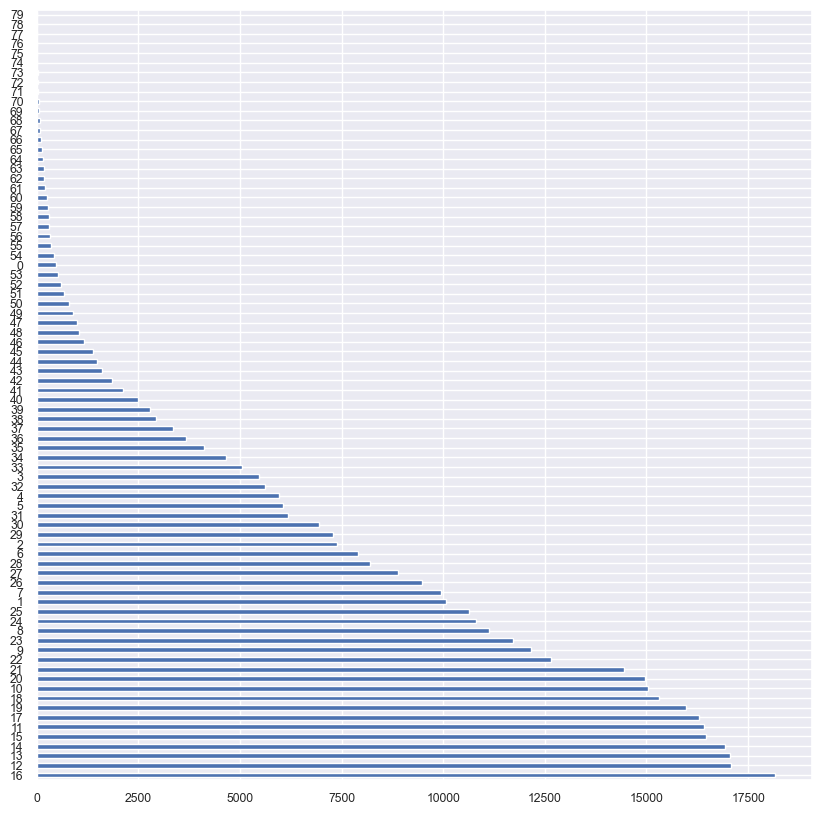

```python
df_wiki_train['stats_word_count'].value_counts().plot(kind='barh', figsize=(10,10));
```

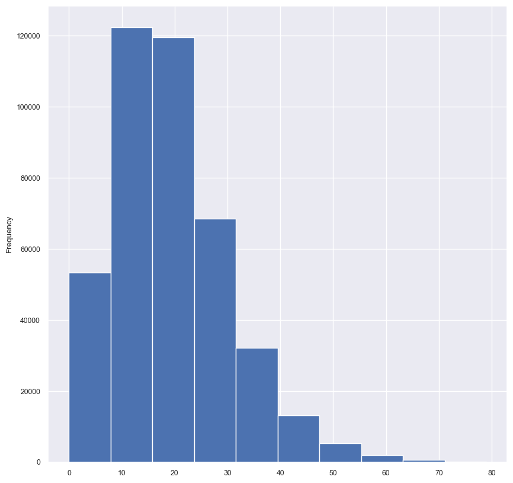

```python
df_wiki_train['stats_word_count'].plot(kind='hist', figsize=(10,10));
```

```python
len(df_wiki_train.query('stats_word_count == 1'))
df_wiki_train.query('stats_word_count == 1').sample(5)
```

```
10061
```

|  | original_text | cleaned_text | label | stats_lrb_count | stats_rrb_count | stats_comma_count | stats_equalsign_count | stats_char_count | stats_image_description | stats_frac_description | stats_file_description | stats_formula_description | stats_language_code | stats_avg_char_per_word | stats_word_count | stats_letter_count | stats_long_word_count | stats_syllable_count | stats_polysyllab_count | stats_monosyllab_count | stats_reading_time | stats_avg_letter_per_word | stats_sentence_length | stats_syllable_avg | stats_mini_word_count | stats_long_numbers_count | stats_lexical_diversity | stats_frac_word_comma | stats_frac_mini_word | … |
| --- | --- | --- | --- | --- | --- | --- | --- | --- | --- | --- | --- | --- | --- | --- | --- | --- | --- | --- | --- | --- | --- | --- | --- | --- | --- | --- | --- | --- | --- | --- |
| 345351 | Dawlish | dawlish | 0 | 0 | 0 | 0 | 0 | 7 | 0 | 0 | 0 | 0 | en | 7.0 | 1 | 7 | 1 | 2 | 0 | 0 | 0.10 | 7.0 | 1.0 | 2.0 | 0 | 0 | 1.0 | 0.0 | 0.0 | … |
| 245554 | Philatelie | philatelie | 0 | 0 | 0 | 0 | 0 | 10 | 0 | 0 | 0 | 0 | en | 10.0 | 1 | 10 | 1 | 3 | 1 | 0 | 0.15 | 10.0 | 1.0 | 3.0 | 0 | 0 | 1.0 | 0.0 | 0.0 | … |
| 290094 | Qatar | qatar | 0 | 0 | 0 | 0 | 0 | 5 | 0 | 0 | 0 | 0 | en | 5.0 | 1 | 5 | 0 | 1 | 0 | 1 | 0.07 | 5.0 | 1.0 | 1.0 | 0 | 0 | 1.0 | 0.0 | 0.0 | … |
| 202216 | Largentière | largentiere | 1 | 0 | 0 | 0 | 0 | 11 | 0 | 0 | 0 | 0 | fr | 11.0 | 1 | 11 | 1 | 3 | 1 | 0 | 0.16 | 11.0 | 1.0 | 3.0 | 0 | 0 | 1.0 | 0.0 | 0.0 | … |
| 301952 | Neotherapsida | neotherapsida | 0 | 0 | 0 | 0 | 0 | 13 | 0 | 0 | 0 | 0 | en | 13.0 | 1 | 13 | 1 | 3 | 1 | 0 | 0.19 | 13.0 | 1.0 | 3.0 | 0 | 0 | 1.0 | 0.0 | 0.0 | … |

```python
len(df_wiki_train.query('stats_word_count == 2'))
df_wiki_train.query('stats_word_count == 2').sample(5)
```

```
7390
```

|  | original_text | cleaned_text | label | stats_lrb_count | stats_rrb_count | stats_comma_count | stats_equalsign_count | stats_char_count | stats_image_description | stats_frac_description | stats_file_description | stats_formula_description | stats_language_code | stats_avg_char_per_word | stats_word_count | stats_letter_count | stats_long_word_count | stats_syllable_count | stats_polysyllab_count | stats_monosyllab_count | stats_reading_time | stats_avg_letter_per_word | stats_sentence_length | stats_syllable_avg | stats_mini_word_count | stats_long_numbers_count | stats_lexical_diversity | stats_frac_word_comma | stats_frac_mini_word | … |
| --- | --- | --- | --- | --- | --- | --- | --- | --- | --- | --- | --- | --- | --- | --- | --- | --- | --- | --- | --- | --- | --- | --- | --- | --- | --- | --- | --- | --- | --- | --- |
| 280654 | Other websites | other websites | 0 | 0 | 0 | 0 | 0 | 13 | 0 | 0 | 0 | 0 | en | 6.5 | 2 | 13 | 1 | 4 | 0 | 0 | 0.19 | 6.5 | 2.0 | 2.0 | 0 | 0 | 1.0 | 0.0 | 0.0 | … |
| 213079 | Table -LRB- information -RRB- | table information | 0 | 1 | 1 | 0 | 0 | 26 | 0 | 0 | 0 | 0 | en | 8.0 | 2 | 16 | 1 | 5 | 1 | 1 | 0.24 | 8.0 | 2.0 | 2.5 | 0 | 0 | 1.0 | 0.0 | 0.0 | … |
| 271307 | Oxides : Dy2O3 | oxides dy2o3 | 0 | 0 | 0 | 0 | 0 | 12 | 0 | 0 | 0 | 0 | fr | 5.5 | 2 | 11 | 0 | 3 | 0 | 1 | 0.16 | 5.5 | 2.0 | 1.5 | 0 | 0 | 1.0 | 0.0 | 0.0 | … |
| 354765 | Other websites | other websites | 0 | 0 | 0 | 0 | 0 | 13 | 0 | 0 | 0 | 0 | en | 6.5 | 2 | 13 | 1 | 4 | 0 | 0 | 0.19 | 6.5 | 2.0 | 2.0 | 0 | 0 | 1.0 | 0.0 | 0.0 | … |
| 281344 | Before politics | before politics | 0 | 0 | 0 | 0 | 0 | 14 | 0 | 0 | 0 | 0 | en | 7.0 | 2 | 14 | 1 | 4 | 0 | 0 | 0.21 | 7.0 | 2.0 | 2.0 | 0 | 0 | 1.0 | 0.0 | 0.0 | … |

```python
len(df_wiki_train.query('stats_word_count == 3'))
df_wiki_train.query('stats_word_count == 3').sample(5)
```

```
5479
```

|  | original_text | cleaned_text | label | stats_lrb_count | stats_rrb_count | stats_comma_count | stats_equalsign_count | stats_char_count | stats_image_description | stats_frac_description | stats_file_description | stats_formula_description | stats_language_code | stats_avg_char_per_word | stats_word_count | stats_letter_count | stats_long_word_count | stats_syllable_count | stats_polysyllab_count | stats_monosyllab_count | stats_reading_time | stats_avg_letter_per_word | stats_sentence_length | stats_syllable_avg | stats_mini_word_count | stats_long_numbers_count | stats_lexical_diversity | stats_frac_word_comma | stats_frac_mini_word | … |
| --- | --- | --- | --- | --- | --- | --- | --- | --- | --- | --- | --- | --- | --- | --- | --- | --- | --- | --- | --- | --- | --- | --- | --- | --- | --- | --- | --- | --- | --- | --- |
| 415006 | Language name Kamviri | language name kamviri | 0 | 0 | 0 | 0 | 0 | 19 | 0 | 0 | 0 | 0 | en | 6.33 | 3 | 19 | 2 | 5 | 0 | 1 | 0.28 | 6.33 | 3.0 | 1.7 | 0 | 0 | 1.0 | 0.000000 | 0.000000 | … |
| 111090 | Robert Christgau link | robert christgau link | 1 | 0 | 0 | 0 | 0 | 19 | 0 | 0 | 0 | 0 | eu | 6.33 | 3 | 19 | 1 | 4 | 0 | 2 | 0.28 | 6.33 | 3.0 | 1.3 | 0 | 0 | 1.0 | 0.000000 | 0.000000 | … |
| 382755 | Crabs as food | crabs as food | 0 | 0 | 0 | 0 | 0 | 11 | 0 | 0 | 0 | 0 | en | 3.67 | 3 | 11 | 0 | 3 | 0 | 3 | 0.16 | 3.67 | 3.0 | 1.0 | 1 | 0 | 1.0 | 0.000000 | 0.333333 | … |
| 405075 | Bricostore in Europe | bricostore in europe | 0 | 0 | 0 | 0 | 0 | 18 | 0 | 0 | 0 | 0 | en | 6.00 | 3 | 18 | 1 | 4 | 0 | 2 | 0.26 | 6.00 | 3.0 | 1.3 | 1 | 0 | 1.0 | 0.000000 | 0.333333 | … |
| 358694 | '' Ermann & Grapow , op . | ermann grapow op | 0 | 0 | 0 | 1 | 0 | 19 | 0 | 0 | 0 | 0 | nl | 4.67 | 3 | 14 | 0 | 4 | 0 | 2 | 0.21 | 4.67 | 3.0 | 1.3 | 1 | 0 | 1.0 | 0.333333 | 0.333333 | … |

```python
len(df_wiki_train.query('stats_word_count == 4'))
df_wiki_train.query('stats_word_count == 4').sample(10)
```

```
5965
```

|  | original_text | cleaned_text | label | stats_lrb_count | stats_rrb_count | stats_comma_count | stats_equalsign_count | stats_char_count | stats_image_description | stats_frac_description | stats_file_description | stats_formula_description | stats_language_code | stats_avg_char_per_word | stats_word_count | stats_letter_count | stats_long_word_count | stats_syllable_count | stats_polysyllab_count | stats_monosyllab_count | stats_reading_time | stats_avg_letter_per_word | stats_sentence_length | stats_syllable_avg | stats_mini_word_count | stats_long_numbers_count | stats_lexical_diversity | stats_frac_word_comma | stats_frac_mini_word | … |
| --- | --- | --- | --- | --- | --- | --- | --- | --- | --- | --- | --- | --- | --- | --- | --- | --- | --- | --- | --- | --- | --- | --- | --- | --- | --- | --- | --- | --- | --- | --- |
| 411655 | Laigny is a commune . | laigny is a commune | 0 | 0 | 0 | 0 | 0 | 17 | 0 | 0 | 0 | 0 | en | 4.00 | 4 | 16 | 1 | 5 | 0 | 3 | 0.24 | 4.00 | 4.0 | 1.3 | 2 | 0 | 1.0 | 0.00 | 0.50 | … |
| 222230 | Teams in the AFC | teams in the afc | 0 | 0 | 0 | 0 | 0 | 13 | 0 | 0 | 0 | 0 | en | 3.25 | 4 | 13 | 0 | 4 | 0 | 4 | 0.19 | 3.25 | 4.0 | 1.0 | 3 | 0 | 1.0 | 0.00 | 0.75 | … |
| 293625 | Wikipedia in other languages | wikipedia in other languages | 0 | 0 | 0 | 0 | 0 | 25 | 0 | 0 | 0 | 0 | en | 6.25 | 4 | 25 | 2 | 8 | 1 | 1 | 0.37 | 6.25 | 4.0 | 2.0 | 1 | 0 | 1.0 | 0.00 | 0.25 | … |
| 399375 | See also Table salt | see also table salt | 0 | 0 | 0 | 0 | 0 | 16 | 0 | 0 | 0 | 0 | en | 4.00 | 4 | 16 | 0 | 4 | 0 | 4 | 0.24 | 4.00 | 4.0 | 1.0 | 1 | 0 | 1.0 | 0.00 | 0.25 | … |
| 148078 | For example , expands to . | for example expands to | 1 | 0 | 0 | 1 | 0 | 21 | 0 | 0 | 0 | 0 | en | 4.75 | 4 | 19 | 2 | 6 | 0 | 2 | 0.28 | 4.75 | 4.0 | 1.5 | 2 | 0 | 1.0 | 0.25 | 0.50 | … |
| 254536 | Territory of Wake Island . | territory of wake island | 0 | 0 | 0 | 0 | 0 | 22 | 0 | 0 | 0 | 0 | en | 5.25 | 4 | 21 | 1 | 7 | 1 | 2 | 0.31 | 5.25 | 4.0 | 1.8 | 1 | 0 | 1.0 | 0.00 | 0.25 | … |
| 272798 | Late of the Pier | late of the pier | 0 | 0 | 0 | 0 | 0 | 13 | 0 | 0 | 0 | 0 | en | 3.25 | 4 | 13 | 0 | 4 | 0 | 4 | 0.19 | 3.25 | 4.0 | 1.0 | 2 | 0 | 1.0 | 0.00 | 0.50 | … |
| 294157 | Abbotsford may refer to : | abbotsford may refer to | 0 | 0 | 0 | 0 | 0 | 21 | 0 | 0 | 0 | 0 | en | 5.00 | 4 | 20 | 1 | 6 | 1 | 3 | 0.29 | 5.00 | 4.0 | 1.5 | 2 | 0 | 1.0 | 0.00 | 0.50 | … |
| 108549 | nausea , and copious vomiting ; | nausea and copious vomiting | 1 | 0 | 0 | 1 | 0 | 26 | 0 | 0 | 0 | 0 | en | 6.00 | 4 | 24 | 2 | 8 | 1 | 1 | 0.35 | 6.00 | 4.0 | 2.0 | 1 | 0 | 1.0 | 0.25 | 0.25 | … |
| 58251 | Richmond is located at . | richmond is located at | 1 | 0 | 0 | 0 | 0 | 20 | 0 | 0 | 0 | 0 | en | 4.75 | 4 | 19 | 2 | 6 | 0 | 2 | 0.28 | 4.75 | 4.0 | 1.5 | 2 | 0 | 1.0 | 0.00 | 0.50 | … |

```python
len(df_wiki_train.query('stats_word_count == 5'))
df_wiki_train.query('stats_word_count == 5').sample(10)
```

```
6066
```

|  | original_text | cleaned_text | label | stats_lrb_count | stats_rrb_count | stats_comma_count | stats_equalsign_count | stats_char_count | stats_image_description | stats_frac_description | stats_file_description | stats_formula_description | stats_language_code | stats_avg_char_per_word | stats_word_count | stats_letter_count | stats_long_word_count | stats_syllable_count | stats_polysyllab_count | stats_monosyllab_count | stats_reading_time | stats_avg_letter_per_word | stats_sentence_length | stats_syllable_avg | stats_mini_word_count | stats_long_numbers_count | stats_lexical_diversity | stats_frac_word_comma | stats_frac_mini_word | … |
| --- | --- | --- | --- | --- | --- | --- | --- | --- | --- | --- | --- | --- | --- | --- | --- | --- | --- | --- | --- | --- | --- | --- | --- | --- | --- | --- | --- | --- | --- | --- |
| 305178 | LiÃ vin is a commune . | li vin is a commune | 0 | 0 | 0 | 0 | 0 | 17 | 0 | 0 | 0 | 0 | fr | 3.0 | 5 | 15 | 1 | 6 | 0 | 4 | 0.22 | 3.0 | 5.0 | 1.2 | 4 | 0 | 1.0 | 0.0 | 0.8 | … |
| 37140 | The Crusaders capture Caesarea Maritima . | the crusaders capture caesarea maritima | 1 | 0 | 0 | 0 | 0 | 36 | 0 | 0 | 0 | 0 | en | 7.0 | 5 | 35 | 4 | 8 | 0 | 2 | 0.51 | 7.0 | 5.0 | 1.6 | 1 | 0 | 1.0 | 0.0 | 0.2 | … |
| 315606 | Captain Ernst Vanselow , the navy . | captain ernst vanselow the navy | 0 | 0 | 0 | 1 | 0 | 29 | 0 | 0 | 0 | 0 | en | 5.4 | 5 | 27 | 2 | 6 | 0 | 4 | 0.40 | 5.4 | 5.0 | 1.2 | 1 | 0 | 1.0 | 0.2 | 0.2 | … |
| 354918 | 1992 Bring Em Back Alive | 1992 bring em back alive | 0 | 0 | 0 | 0 | 0 | 20 | 0 | 0 | 0 | 0 | pt | 4.0 | 5 | 20 | 0 | 5 | 0 | 5 | 0.29 | 4.0 | 5.0 | 1.0 | 1 | 0 | 1.0 | 0.0 | 0.2 | … |
| 234096 | List of named Amor asteroids | list of named amor asteroids | 0 | 0 | 0 | 0 | 0 | 24 | 0 | 0 | 0 | 0 | en | 4.8 | 5 | 24 | 1 | 7 | 1 | 4 | 0.35 | 4.8 | 5.0 | 1.4 | 1 | 0 | 1.0 | 0.0 | 0.2 | … |
| 151017 | ICONS - a portrait of England . | icons a portrait of england | 1 | 0 | 0 | 0 | 0 | 25 | 0 | 0 | 0 | 0 | en | 4.6 | 5 | 23 | 2 | 7 | 0 | 3 | 0.34 | 4.6 | 5.0 | 1.4 | 2 | 0 | 1.0 | 0.0 | 0.4 | … |
| 56639 | Vortex may also refer to : | vortex may also refer to | 1 | 0 | 0 | 0 | 0 | 21 | 0 | 0 | 0 | 0 | en | 4.0 | 5 | 20 | 0 | 6 | 0 | 4 | 0.29 | 4.0 | 5.0 | 1.2 | 2 | 0 | 1.0 | 0.0 | 0.4 | … |
| 332395 | , Long Beach , California , United States | long beach california united states | 0 | 0 | 0 | 3 | 0 | 34 | 0 | 0 | 0 | 0 | en | 6.2 | 5 | 31 | 1 | 7 | 1 | 4 | 0.46 | 6.2 | 5.0 | 1.4 | 0 | 0 | 1.0 | 0.6 | 0.0 | … |
| 350436 | This is finance for people . | this is finance for people | 0 | 0 | 0 | 0 | 0 | 23 | 0 | 0 | 0 | 0 | en | 4.4 | 5 | 22 | 1 | 6 | 0 | 4 | 0.32 | 4.4 | 5.0 | 1.2 | 2 | 0 | 1.0 | 0.0 | 0.4 | … |
| 142533 | Slash chord , in popular music | slash chord in popular music | 1 | 0 | 0 | 1 | 0 | 25 | 0 | 0 | 0 | 0 | en | 4.8 | 5 | 24 | 1 | 8 | 1 | 3 | 0.35 | 4.8 | 5.0 | 1.6 | 1 | 0 | 1.0 | 0.2 | 0.2 | … |

```python
t_end = time.time()
total_runtime = t_end-t_start
total_runtime_min = round((total_runtime/60),2)
print(str(total_runtime_min)+" minutes")
```

```
1.66 minutes
```

```python
if not FASTRUN: send_push(f"Calculate text stats features finished in: {total_runtime_min}")
```

# 7.0 Watermark

```python
%watermark
```

```
Last updated: 2023-02-20T15:29:15.250343+01:00

Python implementation: CPython
Python version       : 3.9.0
IPython version      : 8.9.0

Compiler    : Clang 11.0.0
OS          : Darwin
Release     : 22.3.0
Machine     : arm64
Processor   : arm
CPU cores   : 10
Architecture: 64bit
```

```python
%watermark --iversions
```

```
pandas  : 1.5.3
seaborn : 0.12.2
re      : 2.2.1
textstat: 0.7.2
numpy   : 1.23.5
```

```python
output_file = f'{ROOT_PATH}{PATH_DATA_HTML}{today}_01.01_data_cleaning_and_text_stats_features_GC.html'
!jupyter nbconvert --to html "01.01_data_cleaning_and_text_stats_features_GC.ipynb" --output {output_file}
```

```
[NbConvertApp] Converting notebook 01.01_data_cleaning_and_text_stats_features_GC.ipynb to html
[NbConvertApp] Writing 711228 bytes to ../reports/html/2023-02-20_01.01_data_cleaning_and_text_stats_features_GC.html
```